# Week 1 - Data Analysis & Visualization in R

#### PBHLTH W142: UC Berkeley School of Public Health

> Author: Xander Posner, Graduate Student Instructor

> xander@berkeley.edu

### Tools Used in this Tutorial

In this tutorial, we will:

- Get to know the Western Collaborative Group Study (wcgs) dataset from the `epitools` package
- Change some variable types (e.g., numeric to factor)
- Create a new BMI variable based on existing height and weight measurements
- Generate summary statistics and figures
- Interpret your summary statistics and figures

### R Packages Used in this Tutorial

- `“tidyverse”`
- `“epitools”`

When practicing on your own in RStudio, you will first need to install each of these packages using the `install.packages("")` function, putting the name(s) of the package(s) inside the quotation marks like this:

> `install.packages(“tidyverse”)` OR `install.packages(c(“tidyverse”, “epitools”))`

You **won’t** need to *install* packages more than once on the same computer.

After installing, you must load each package library **separately**, using the `library()` function, putting the name of each package inside the parentheses without quotation marks like this:

> `library(tidyverse)`

> `library(epitools)`

You **will** need to *load* packages each time you need to use them, using the `library()` function whenever you initiate a new R session.

**You don’t need to install any packages for this tutorial**. Just press **check** to run any chunk with a `library()` function in it.

### R Functions Used in this Tutorial

- `library()` to load each package library
- `data()` to read built-in datasets into R
- `head()` to view the first few lines of your dataset
- `nrow()` to view the number of rows in your dataset
- `str()` to view the “structure” of your dataset, including variable names and types
- `summary()` to produce summary statistics
- `ggplot()`, `geom_histogram()`, `geom_boxplot()`, and `geom_col()` to create histograms, boxplots, and bar charts

Click the “Go to next exercise…” button to continue.

## Exercise 1 – Get Started

Some code chunks are finished for you; just press **check** to proceed. Other chunks require you to modify and/or add code before pressing **check** to move through the tutorial.

If you get stuck, use the **hint** in each code chunk first. If you’re still having trouble, head to Piazza and post your question.

**Make sure you run each chunk in order!**

### Get to Know Your Data

1. The `wcgs` dataset is built into the `epitools` package. As long as you load the libraries first using the `library()` functions, you will be able to load the dataset by calling `data(wcgs)` as shown below. Click “check” to continue.

```r
#< task
library(epitools)
library(tidyverse) # helps us make charts and graphics
library(readr)
library(markdown)
library(DescTools)

data(wcgs)
```

2. Now that the `wcgs` dataset is loaded into your environment, use the `head()` function to view the first six rows.

```r
#< task
head(wcgs) # view the first six rows of the dataset in table format
```

```
##     id age0 height0 weight0 sbp0 dbp0 chol0 behpat0 ncigs0 dibpat0 chd69
## 1 2001   49      73     150  110   76   225       2     25       1     0
## 2 2002   42      70     160  154   84   177       2     20       1     0
## 3 2003   42      69     160  110   78   181       3      0       0     0
## 4 2004   41      68     152  124   78   132       4     20       0     0
## 5 2005   59      70     150  144   86   255       3     20       0     1
## 6 2006   44      72     204  150   90   182       4      0       0     0
##   typechd time169 arcus0
## 1       0    1664      0
## 2       0    3071      1
## 3       0    3071      0
## 4       0    3064      0
## 5       1    1885      1
## 6       0    3102      0
```

3. Use the `nrow()` function to calculate the number of rows in your dataset, which here amounts to our sample size, $n$.

```r
#< task
n <- nrow(wcgs)
```

Notice that when we assigned the `nrow()` function to the `object` named `n`, R doesn’t immediately *print* the result. Instead the resulting value is saved in your `Global Environment`.

4. Here are the ways you can have the results of a function print to your Console. Press **check** to observe.

```r
#< task
nrow(wcgs) # PRINTS to the console but DOES NOT save the value
```

```
## [1] 3154
```

```r
n <- nrow(wcgs) # SAVES the value but DOES NOT print

n # PRINTS out the results that you previously saved above
```

```
## [1] 3154
```

```r
n + 1 # adds 1 to the value saved in the n object: example of what you can do with stored objects in your environment
```

```
## [1] 3155
```

```r
print(n <- nrow(wcgs)) # SAVES the value AND also PRINTS to the console in one step
```

```
## [1] 3154
```

**NOTE. R is cAsE sEnSiTiVe.**`N` would be an entirely separate object from `n` from R’s perspective.

### Summarizing your data

R has many ways to view summary statistics. The simplest is the `summary()` function.

5. Run the chunk below to see what summary statistics the `summary()` function produces.

```r
#< task
summary(wcgs)
```

```
##        id             age0          height0         weight0         sbp0
##  Min.   : 2001   Min.   :39.00   Min.   :60.00   Min.   : 78   Min.   : 98.0
##  1st Qu.: 3741   1st Qu.:42.00   1st Qu.:68.00   1st Qu.:155   1st Qu.:120.0
##  Median :11406   Median :45.00   Median :70.00   Median :170   Median :126.0
##  Mean   :10478   Mean   :46.28   Mean   :69.78   Mean   :170   Mean   :128.6
##  3rd Qu.:13115   3rd Qu.:50.00   3rd Qu.:72.00   3rd Qu.:182   3rd Qu.:136.0
##  Max.   :22101   Max.   :59.00   Max.   :78.00   Max.   :320   Max.   :230.0
##
##       dbp0            chol0          behpat0          ncigs0
##  Min.   : 58.00   Min.   :103.0   Min.   :1.000   Min.   : 0.0
##  1st Qu.: 76.00   1st Qu.:197.2   1st Qu.:2.000   1st Qu.: 0.0
##  Median : 80.00   Median :223.0   Median :2.000   Median : 0.0
##  Mean   : 82.02   Mean   :226.4   Mean   :2.523   Mean   :11.6
##  3rd Qu.: 86.00   3rd Qu.:253.0   3rd Qu.:3.000   3rd Qu.:20.0
##  Max.   :150.00   Max.   :645.0   Max.   :4.000   Max.   :99.0
##                   NA's   :12
##     dibpat0           chd69            typechd          time169
##  Min.   :0.0000   Min.   :0.00000   Min.   :0.0000   Min.   :  18
##  1st Qu.:0.0000   1st Qu.:0.00000   1st Qu.:0.0000   1st Qu.:2842
##  Median :1.0000   Median :0.00000   Median :0.0000   Median :2942
##  Mean   :0.5038   Mean   :0.08148   Mean   :0.1363   Mean   :2684
##  3rd Qu.:1.0000   3rd Qu.:0.00000   3rd Qu.:0.0000   3rd Qu.:3037
##  Max.   :1.0000   Max.   :1.00000   Max.   :3.0000   Max.   :3430
##
##      arcus0
##  Min.   :0.0000
##  1st Qu.:0.0000
##  Median :0.0000
##  Mean   :0.2985
##  3rd Qu.:1.0000
##  Max.   :1.0000
##  NA's   :2
```

You will notice the `summary()` function prints out the following values for each variable in the `wcgs` dataset:

- The minimum value
- The value at Q1, the first quartile (25th percentile)
- The median value or Q2 (50th percentile)
- The mean (average) value
- The value at Q3, the third quartile (75th percentile)
- The maximum value
6. Use the dollar sign `$` to access different variables in your dataset. The first one is done for you. Fill in the code below to summarize the `height0` variable.

```r
#< task
summary_age0 <- summary(wcgs$age0)
summary_age0
```

```
##    Min. 1st Qu.  Median    Mean 3rd Qu.    Max.
##   39.00   42.00   45.00   46.28   50.00   59.00
```

```r
#< task_notest
summary_height0 <- "<<<<<<YOUR CODE HERE>>>>>>"
summary_height0
```

```
## [1] "<<<<<<YOUR CODE HERE>>>>>>"
```

```r
summary_height0 <- summary(wcgs$height0)
summary_height0
```

```
##    Min. 1st Qu.  Median    Mean 3rd Qu.    Max.
##   60.00   68.00   70.00   69.78   72.00   78.00
```

## Exercise 2 – Modify Your Dataset

### Make Factor Variables

1. First, view the structure of your dataset using the `str()` function. Click **Check** to observe. Notice the different variable “types.”

```r
#< task
str(wcgs)
```

```
## 'data.frame':    3154 obs. of  14 variables:
##  $ id     : int  2001 2002 2003 2004 2005 2006 2007 2008 2009 2010 ...
##  $ age0   : int  49 42 42 41 59 44 44 40 43 42 ...
##  $ height0: int  73 70 69 68 70 72 72 71 72 70 ...
##  $ weight0: int  150 160 160 152 150 204 164 150 190 175 ...
##  $ sbp0   : int  110 154 110 124 144 150 130 138 146 132 ...
##  $ dbp0   : int  76 84 78 78 86 90 84 60 76 90 ...
##  $ chol0  : int  225 177 181 132 255 182 155 140 149 325 ...
##  $ behpat0: int  2 2 3 4 3 4 4 2 3 2 ...
##  $ ncigs0 : int  25 20 0 20 20 0 0 0 25 0 ...
##  $ dibpat0: int  1 1 0 0 0 0 0 1 0 1 ...
##  $ chd69  : int  0 0 0 0 1 0 0 0 0 0 ...
##  $ typechd: int  0 0 0 0 1 0 0 0 0 0 ...
##  $ time169: int  1664 3071 3071 3064 1885 3102 3074 3071 3064 1032 ...
##  $ arcus0 : int  0 1 0 0 1 0 0 0 0 1 ...
```

```r
#< task
wcgs$dibpat0_fact <- factor(wcgs$dibpat0, ordered = TRUE, labels = c("A","B"))
```

3. Now create a new variable called `smoker0` that is equal to 1 if someone currently smokes any cigarettes and 0 if they don’t

```r
#< task
wcgs$smoker0[wcgs$ncigs0 > 0] <- 1 # creates a new variable called smoker0 and sets the value to 1 for all individuals with ncigs0 > 0

wcgs$smoker0[wcgs$ncigs0 == 0] <- 0 # sets the value of smoker0 to 0 for all individuals with ncigs = 0.
```

The square brackets indicate an R operation called “subsetting.” This operation tells R to set the value of `smoker0` to 0 if the `ncigs0` value for that individual is 0.

**Note that we had to use two equal signs (==) when we specified the second condition for subsetting.**

#### Options for Subsetting Conditions

- `dataset$variable >= B`

(greater than or equal to some number B)

4. Now try making a “yes/no” factor variable for systolic blood pressure, `sbp0`, just like we did for smoking above. Call the new variable `highsbp0` and set it equal to 1 if `sbp0` is greater than or equal to 140, and set it equal to 0 if `sbp0` is less than 140.

```r
#< task_notest
"<<<<<<YOUR CODE HERE>>>>>>" <- 1

"<<<<<<YOUR CODE HERE>>>>>>" <- 0
wcgs$highsbp0[wcgs$sbp0 >= 140] <- 1

wcgs$highsbp0[wcgs$sbp0 < 140] <- 0

# now make highsbp0 a factor variable with 2 levels

wcgs$highsbp0 <- factor(wcgs$highsbp0, labels = c("normal sbp", "high sbp"))
```

### Create a new BMI variable

The `wcgs` dataset has the height variable, `height0`, in inches (in) and the weight variable, `weight0`, in pounds (lbs). We want to analyze BMI, which is equal to weight (mass) in kilograms divided by height in meters squared, so we’ll have to convert height to centimeters (cm) and weight to kilograms (kg).

5. Create new variables for height, weight, and BMI in the wcgs dataset by using the assignment operator (<-) like so:

```r
#< task
wcgs$heightcm0 <- round(wcgs$height0 * 2.54, digits = 2)
# this line of code tells R to take the Height0 value for each individual (row) in the wcgs dataset, multiply it by 2.54, round the result to 2 decimal places (digits), and then add the value to a new variable (column) we named Heightcm0.

wcgs$weightkg0 <- round(wcgs$weight0/2.2, digits = 2)

wcgs$BMI0 <- round(wcgs$weightkg0/((wcgs$heightcm0/100)^2), digits = 1)
```

```r
#< task
wcgs_new <- write_csv(wcgs, "wcgs_data_new.csv")
```

```r
#< task_notest
head(wcgs_new)
```

```
##     id age0 height0 weight0 sbp0 dbp0 chol0 behpat0 ncigs0 dibpat0 chd69
## 1 2001   49      73     150  110   76   225       2     25       1     0
## 2 2002   42      70     160  154   84   177       2     20       1     0
## 3 2003   42      69     160  110   78   181       3      0       0     0
## 4 2004   41      68     152  124   78   132       4     20       0     0
## 5 2005   59      70     150  144   86   255       3     20       0     1
## 6 2006   44      72     204  150   90   182       4      0       0     0
##   typechd time169 arcus0 dibpat0_fact smoker0   highsbp0 heightcm0 weightkg0
## 1       0    1664      0            B       1 normal sbp    185.42     68.18
## 2       0    3071      1            B       1   high sbp    177.80     72.73
## 3       0    3071      0            A       0 normal sbp    175.26     72.73
## 4       0    3064      0            A       1 normal sbp    172.72     69.09
## 5       1    1885      1            A       1   high sbp    177.80     68.18
## 6       0    3102      0            A       0   high sbp    182.88     92.73
##   BMI0
## 1 19.8
## 2 23.0
## 3 23.7
## 4 23.2
## 5 21.6
## 6 27.7
```

## Exercise 3 – Create Histograms & Box Plots

1. Create a histogram for the `sbp0` variable.

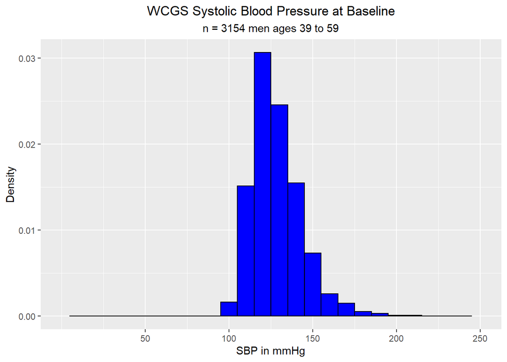

```r
#< task
ggplot(wcgs_new, aes(x = sbp0, y = ..density..)) +
  geom_histogram(binwidth = 10,
                 color = "black",
                 fill = "blue") +
  labs(title = "WCGS Systolic Blood Pressure at Baseline",
       subtitle = "n = 3154 men ages 39 to 59",
       x = "SBP in mmHg", y = "Density" ) +
  scale_x_continuous(limits = c(0, 250),
                     breaks = c(50, 100, 150, 200, 250),
                     labels = c(50, 100, 150, 200, 250)) +
  theme(plot.title = element_text(hjust = 0.5),
        plot.subtitle = element_text(hjust = 0.5))
```

2. Create a box plot for the `sbp0` variable.

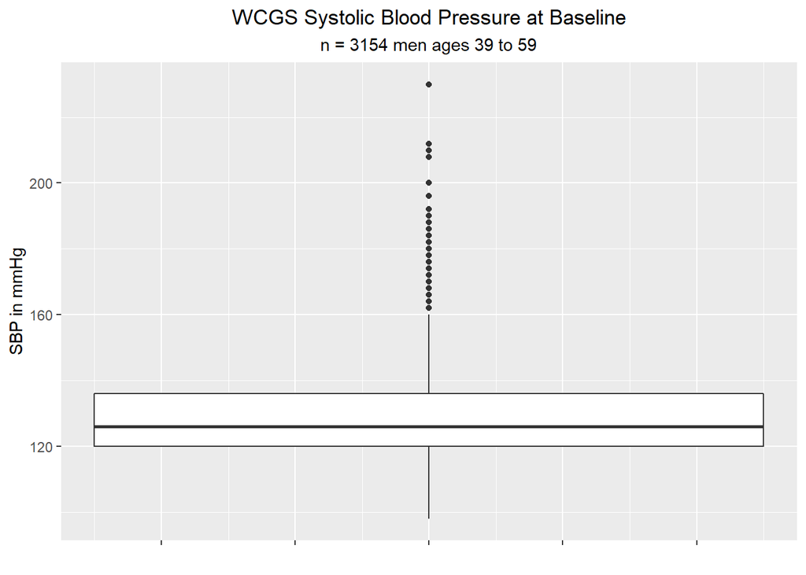

```r
#< task
ggplot(wcgs_new, aes(y = sbp0)) +
  geom_boxplot(width = 0.5) +
  scale_x_continuous(labels = NULL) +
  labs(y = "SBP in mmHg",
       x = "",
       title = "WCGS Systolic Blood Pressure at Baseline",
       subtitle = "n = 3154 men ages 39 to 59") +
  theme(plot.title = element_text(hjust = 0.5),
        plot.subtitle = element_text(hjust = 0.5))
```

3. Create a bar chart for the `sbp0` variable for each level of the `dibpat0` variable.

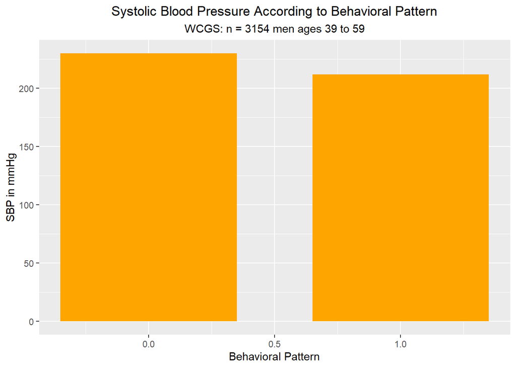

```r
#< task
ggplot(wcgs_new, aes(y = sbp0)) +
  geom_col(aes(x = dibpat0),
           position = "dodge",
           fill = "orange",
           width = 0.7) +
  labs(y = "SBP in mmHg",
       x = "Behavioral Pattern",
       title = "Systolic Blood Pressure According to Behavioral Pattern",
       subtitle = "WCGS: n = 3154 men ages 39 to 59") +
  theme(plot.title = element_text(hjust = 0.5),
        plot.subtitle = element_text(hjust = 0.5))
```

4. Create a two-way table of the behavioral pattern factor variable `dibpat0_fact` and high blood pressure `highsbp0`.

```r
#< task
highsbp_dibpat_table <- table(wcgs_new$dibpat0_fact, wcgs_new$highsbp0)


# You will model your tables in R Lab Workbook 1 on the following two table outputs

addmargins(highsbp_dibpat_table)
```

[output not shown]

```r
round(prop.table(highsbp_dibpat_table), digits = 3)
```

[output not shown]